# **Chapter 13 Probability**

## **13.10 Continuous probability**

Just as when using distributions to summarize numeric data, it is much more practical to define a function that operates on intervals rather than single values. The standard way of doing this is using the *cumulative distribution function* (CDF).

```r
library(tidyverse)
library(dslabs)
data(heights)
x <- heights %>% filter(sex=="Male") %>% pull(height)
```

We defined the empirical distribution function as:

```r
F <- function(a) mean(x<=a)
```

which, for any value `a`, gives the proportion of values in the list `x` that are smaller or equal than `a`.

```r
1 - F(70)
```

```
[1] 0.3768473
```

For instance, the probability of a student being between height `a` and height `b` is:

```r
F(b)-F(a)
```

## **13.11 Theoretical continuous distributions**

The cumulative distribution for the normal distribution is defined by a mathematical formula which in R can be obtained with the function `pnorm`. We say that `a` random quantity is normally distributed with average `m` and standard deviation `s` if its probability distribution is defined by:

```r
F(a) = pnorm(a, m, s)
```

```r
m <- mean(x)
s <- sd(x)
1 - pnorm(70.5, m, s)
```

```
[1] 0.371369
```

### 13.11.1 Theoretical distributions as approximations

The normal distribution is derived mathematically: we do not need data to define it.

With continuous distributions, the probability of a singular value is not even defined. For example, it does not make sense to ask what is the probability that a normally distributed value is 70. Instead, we define probabilities for intervals. We thus could ask what is the probability that someone is between 69.5 and 70.5.

In cases like height, in which the data is rounded, the normal approximation is particularly useful if we deal with intervals that include exactly one round number. For example, the normal distribution is useful for approximating the proportion of students reporting values in intervals like the following three:

```r
mean(x <= 68.5) - mean(x <= 67.5)
```

```
[1] 0.114532
```

```r
mean(x <= 69.5) - mean(x <= 68.5)
```

```
[1] 0.1194581
```

```r
mean(x <= 70.5) - mean(x <= 69.5)
```

```
[1] 0.1219212
```

```r
pnorm(68.5, m, s) - pnorm(67.5, m, s)
```

```
[1] 0.1031077
```

```r
pnorm(69.5, m, s) - pnorm(68.5, m, s)
```

```
[1] 0.1097121
```

```r
pnorm(70.5, m, s) - pnorm(69.5, m, s)
```

```
[1] 0.1081743
```

However, the approximation is not as useful for other intervals. For instance, notice how the approximation breaks down when we try to estimate:

```r
mean(x <= 70.9) - mean(x<=70.1)
```

```
[1] 0.02216749
```

with

```r
pnorm(70.9, m, s) - pnorm(70.1, m, s)
```

```
[1] 0.08359562
```

### 13.11.2 The probability density

For categorical distributions, we can define the probability of a category. For example, a roll of a die, let’s call it **X**, can be 1,2,3,4,5 or 6. The probability of 4 is defined as:
$$Pr(X = 4) = 1/6$$

The CDF can then easily be defined:
$$F(4) = Pr(X ≤ 4) = Pr(X = 4) + Pr(X = 3) + Pr(X = 2) + Pr(X = 1)$$

The probability density at **x** is defined as the function **f(a)** such that:
$$F(a) = Pr(X ≤ a) = ∫^a f(x)dx$$
For example, to use the normal approximation to estimate the probability of someone being taller than 76 inches, we use:

```r
1 - pnorm(76, m, s)
```

```
[1] 0.03206008
```

## **13.12 Monte Carlo simulations for continuous variables**

R provides functions to generate normally distributed outcomes. Specifically, the `rnorm` function takes three arguments: size, average (defaults to 0), and standard deviation (defaults to 1) and produces random numbers.

```r
n <- length(x)
m <- mean(x)
s <- sd(x)
simulated_heights <- rnorm(n, m, s)
```

If, for example, we pick 800 males at random, what is the distribution of the tallest person? How rare is a seven footer in a group of 800 males? The following Monte Carlo simulation helps us answer that question:

```r
B <- 10000
tallest <- replicate(B, {
  simulated_data <- rnorm(800, m, s)
  max(simulated_data)
})
```

Having a seven footer is quite rare:

```r
mean(tallest >= 7*12)
```

```
[1] 0.0192
```

## **13.13 Continuous distributions**

We have already seen the functions `dnorm`, `pnorm`, and `rnorm` for the normal distribution. The functions `qnorm` gives us the quantiles. We can therefore draw a distribution like this:

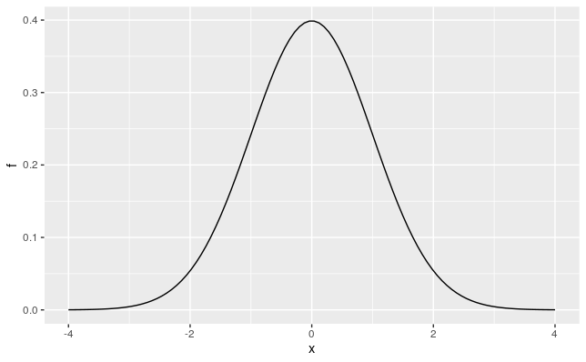

```r
x <- seq(-4, 4, length.out = 100)
qplot(x, f, geom = "line", data = data.frame(x, f = dnorm(x)))
```

## **13.14 Exercises**

**1. Assume the distribution of female heights is approximated by a normal distribution with a mean of 64 inches and a standard deviation of 3 inches. If we pick a female at random, what is the probability that she is 5 feet or shorter?**

```r
pnorm(60, 64, 3)
```

```
[1] 0.09121122
```

**2. Assume the distribution of female heights is approximated by a normal distribution with a mean of 64 inches and a standard deviation of 3 inches. If we pick a female at random, what is the probability that she is 6 feet or taller?**

```r
1 - pnorm(72, 64, 3)
```

```
[1] 0.003830381
```

**3. Assume the distribution of female heights is approximated by a normal distribution with a mean of 64 inches and a standard deviation of 3 inches. If we pick a female at random, what is the probability that she is between 61 and 67 inches?**

```r
pnorm(67, 64, 3) - pnorm(61, 64, 3)
```

```
[1] 0.6826895
```

**4. Repeat the exercise above, but convert everything to centimeters. That is, multiply every height, including the standard deviation, by 2.54. What is the answer now?**

```r
pnorm(67*2.54, 64*2.54, 3*2.54) - pnorm(61*2.54, 64*2.54, 3*2.54)
```

```
[1] 0.6826895
```

```r
pnorm(1, 0, 1) - pnorm(-1, 0, 1)
```

```
[1] 0.6826895
```

**6. To see the math that explains why the answers to questions 3, 4, and 5 are the same, suppose we have a random variable with average *m* and standard error *s*. Suppose we ask the probability of *X* being smaller or equal to *a*. Remember that, by definition, *a* is *(a-m)/s* standard deviations *s* away from the average *m*. The probability is:**
$$Pr(X ≤ a)$$
Now we subtract *μ* to both sides and then divide both sides by *σ*:
$$Pr(X-m/s ≤ a-m/s)$$

The quantity on the left is a standard normal random variable. It has an average of 0 and a standard error of 1. We will call it *Z*:
$$Pr(Z ≤ a-m/s)$$
So, no matter the units, the probability of *X≤a* is the same as the probability of a standard normal variable being less than *(a−m)/s*. If `mu` is the average and `sigma` the standard error, which of the following R code would give us the right answer in every situation:

1. `mean(X<=a)`

**b. `pnorm((a - m)/s)`**

3. `pnorm((a - m)/s, m, s)`
4. `pnorm(a)`

**7. Imagine the distribution of male adults is approximately normal with an expected value of 69 and a standard deviation of 3. How tall is the male in the 99th percentile? Hint: use `qnorm`.**

```r
qnorm(0.99, 69, 3)
```

```
[1] 75.97904
```

**8. The distribution of IQ scores is approximately normally distributed. The average is 100 and the standard deviation is 15. Suppose you want to know the distribution of the highest IQ across all graduating classes if 10,000 people are born each in your school district. Run a Monte Carlo simulation with `B=1000` generating 10,000 IQ scores and keeping the highest. Make a histogram.**

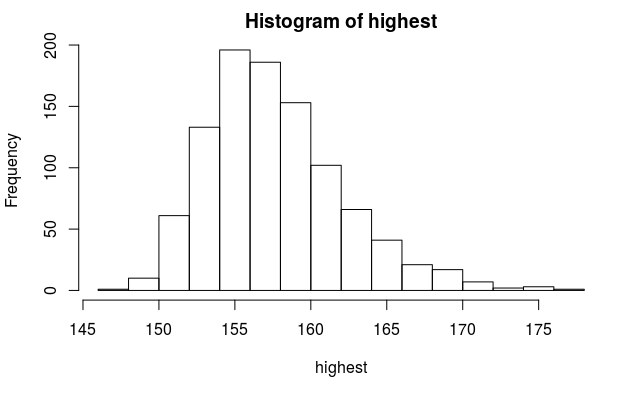

```r
B <- 1000
highest <- replicate(B, {
  simulated_data <- rnorm(10000, 100, 15)
  max(simulated_data)
})

hist(highest)
```